# Documentation on Shiny course project application

Evgeny Gorelov

4/3/2019

## Data set information

The **mtcars** data set is extracted from the 1974 Motor Trend US magazine, and comprises fuel consumption and 10 aspects of automobile design and performance for 32 automobiles (1973–74 models). The data set includes data for **32** cars with **11** variables:

| column | variable | explanation |
| --- | --- | --- |
| [, 1] | mpg | Miles/(US) gallon |
| [, 2] | cyl | Number of cylinders |
| [, 3] | disp | Displacement (cu.in.) |
| [, 4] | hp | Gross horsepower |
| [, 5] | drat | Rear axle ratio |
| [, 6] | wt | Weight (1000 lbs) |
| [, 7] | qsec | 1/4 mile time |
| [, 8] | vs | Engine (0 = V-shaped, 1 = straight) |
| [, 9] | am | Transmission (0 = automatic, 1 = manual) |
| [,10] | gear | Number of forward gears |
| [,11] | carb | Number of carburetors |

## The problem

Studiing the **mtcars** dataset using the linear fit model, illustrate, which variables of the data set should be included into the model, in order to explain fuel consumption differrence between cars wit automatic and manual transmittion.

## Method

Selecting attitional predictor from the list using radiobuttons, build additional linear *fit1* with two predictors, compare it to basis *fit0* with single predictor (type of transmission), and plot obtained linear fit versus additional predictor. The *p-value*, associated with selected additional predictor is also reported, giving an information of significance of the selected predictor to explanation of fuel consumption difference of cars from the data set.

The simplified chunk of code, illustrating the application behavior with Gross horsepower (**hp**) additional predictor selected is shown below:

```r
   fit0<-lm(mpg~am, data=mtcars)
   fit1<-lm(mpg~am+hp, data=mtcars)

   anova(fit0,fit1)$Pr[2]
```

```
## [1] 2.920375e-08
```

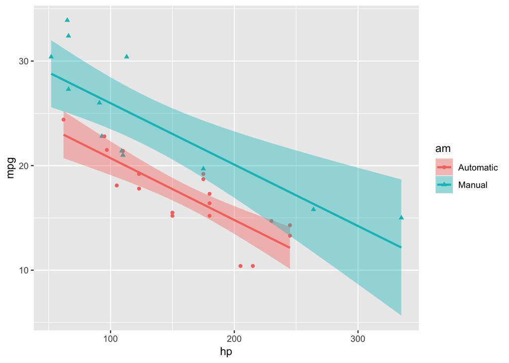

```r
   ggplot(mtcars, aes(hp, mpg, shape=am, colour=am, fill=am))+geom_point()+geom_smooth(method="lm")
```

The application needs the **ggplot2** package to be installed.